Scientific logbook

# Reproducing Olshausen's classical SparseNet (part 3)

Laurent Perrinet

2015-12-11 13:51

Source

This is an old blog post, see the newer version in [this post](https://laurentperrinet.github.io/sciblog/posts/2017-03-16-reproducing-olshausens-classical-sparsenet-part-3.html)

In this notebook, we test the convergence of SparseNet as a function of different learning parameters. This shows the relative robusteness of this method according to the coding parameters, but also the importance of homeostasis to obtain an efficient set of filters:

See also :

- https://laurentperrinet.github.io/sciblog/posts/2015-05-05-reproducing-olshausens-classical-sparsenet.html for a description of how SparseNet is implemented in the scikit-learn package
- https://laurentperrinet.github.io/sciblog/posts/2015-05-06-reproducing-olshausens-classical-sparsenet-part-2.html for a descrtiption of how we managed to implement the homeostasis
- this [PR to sklearn](https://github.com/scikit-learn/scikit-learn/pull/4693)

```python
%matplotlib inline
import matplotlib.pyplot as plt
import numpy as np
np.set_printoptions(precision=2, suppress=True)
```

```python
from shl_scripts import SHL
DEBUG_DOWNSCALE, verbose = 10, 100
DEBUG_DOWNSCALE, verbose = 10, 0
DEBUG_DOWNSCALE, verbose = 1, 0
N_scan = 7
database = '/Users/lolo/pool/science/BICV/SHL_scripts/database/'
```

### 1. With diferent learning rates but without homeostasis

Here,we only ensure the norm ofthe filters is constant.

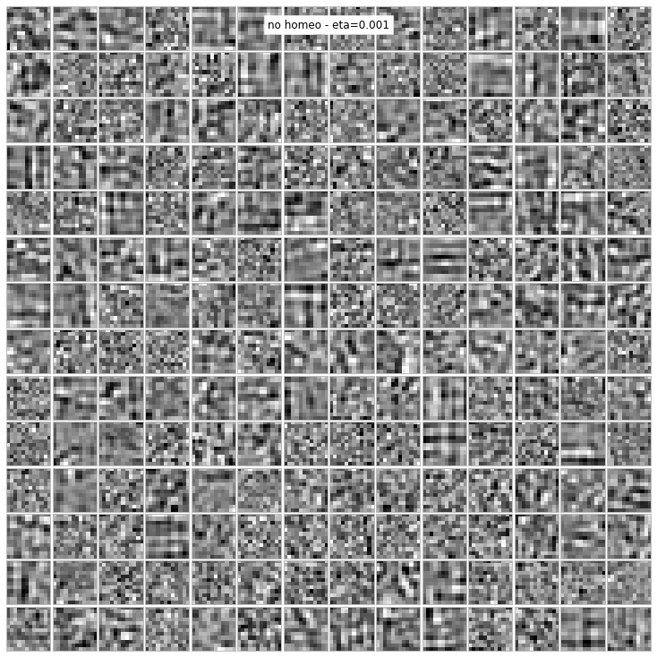

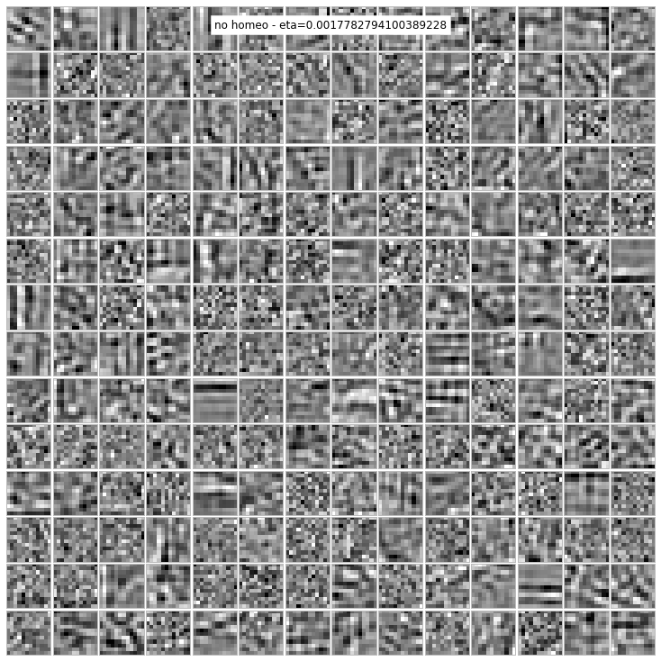

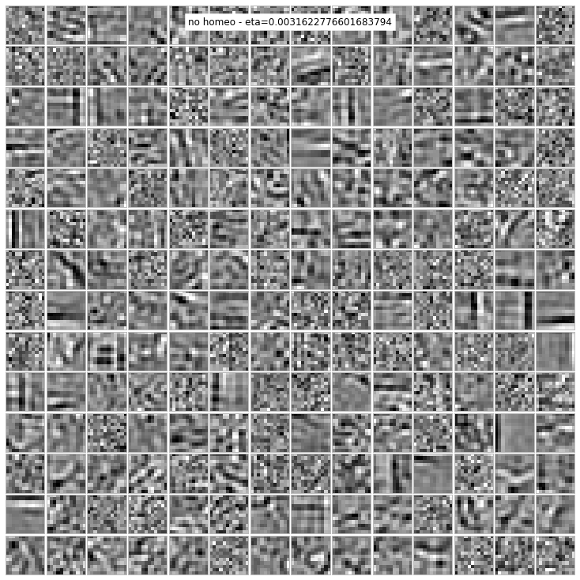

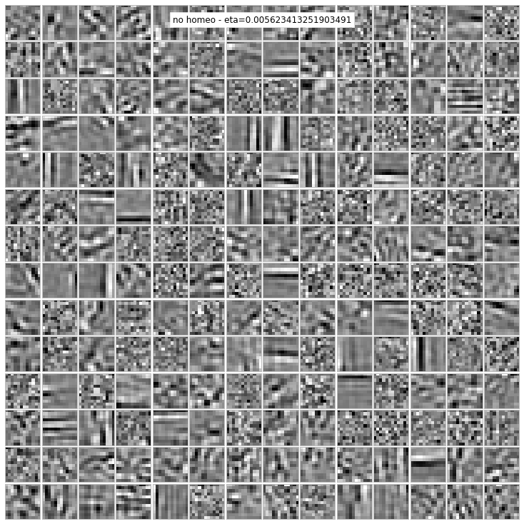

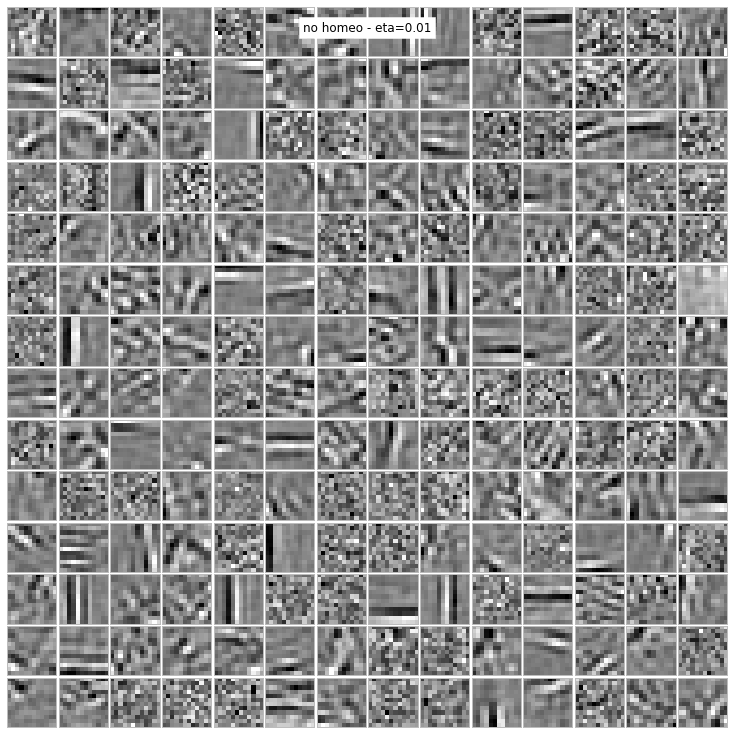

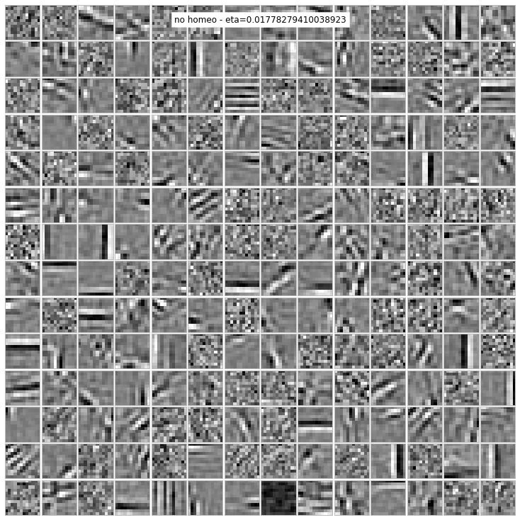

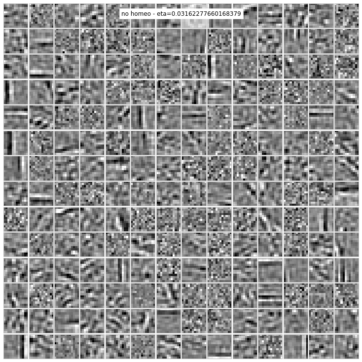

```python
for eta in np.logspace(-3, -1.5, N_scan, base=10):
    shl = SHL(DEBUG_DOWNSCALE=DEBUG_DOWNSCALE, eta_homeo=0, database=database,
              learning_algorithm='omp', eta=eta, verbose=verbose)
    dico = shl.learn_dico()
    _ = shl.show_dico(dico, title='no homeo - eta={}'.format(eta))
```

### 2. Homeostasis à-la-SparseNet

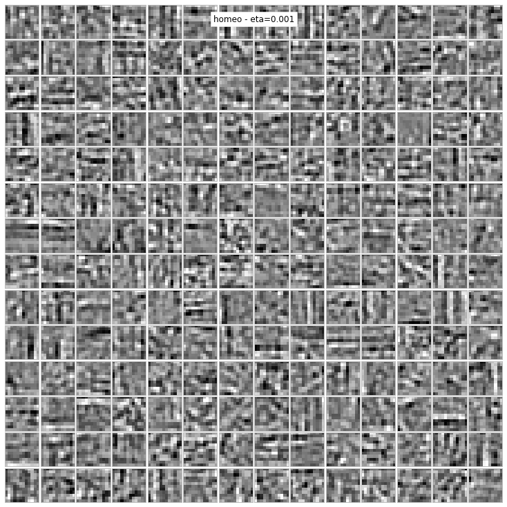

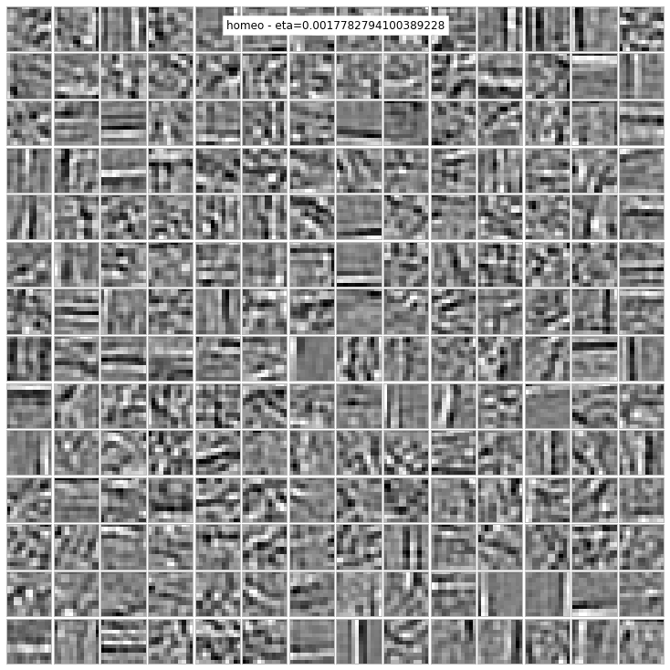

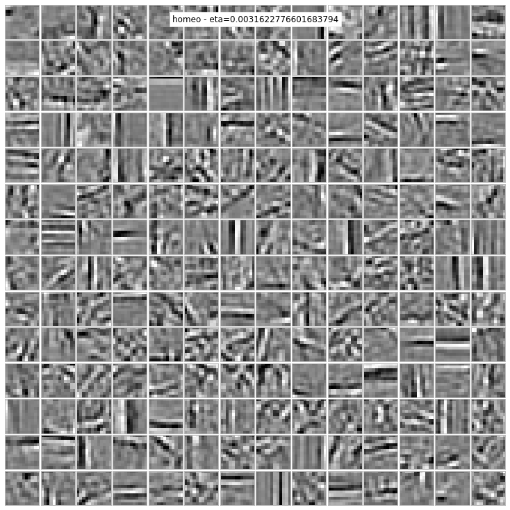

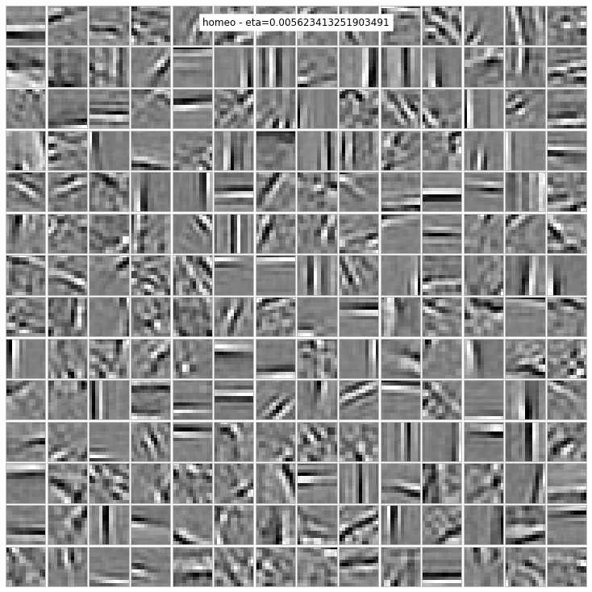

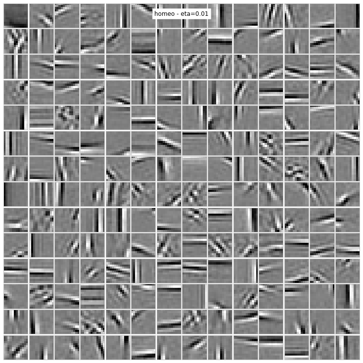

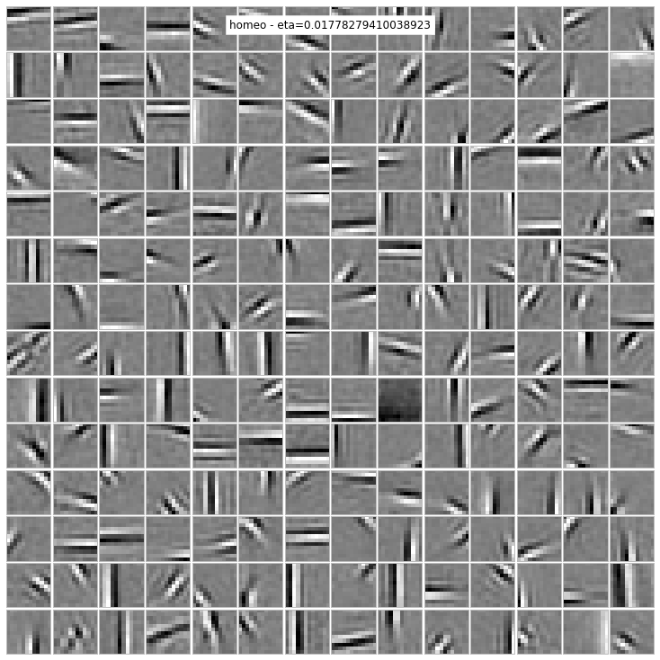

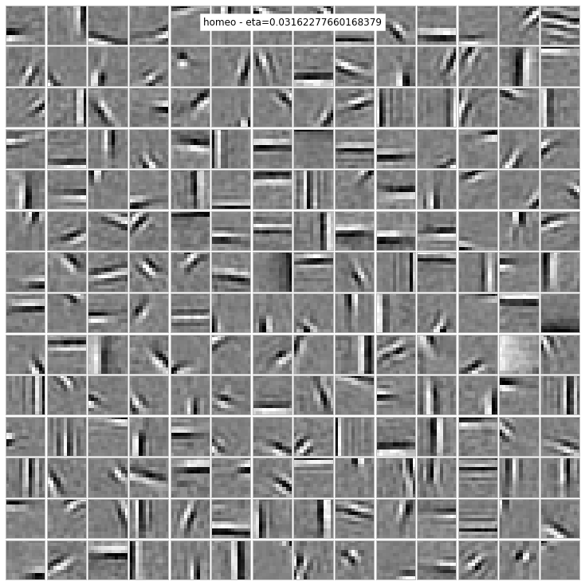

```python
for eta in np.logspace(-3, -1.5, N_scan, base=10):
    shl = SHL(DEBUG_DOWNSCALE=DEBUG_DOWNSCALE, database=database,
              learning_algorithm='omp', eta=eta, verbose=verbose)
    dico = shl.learn_dico()
    _ = shl.show_dico(dico, title='homeo - eta={}'.format(eta))
```

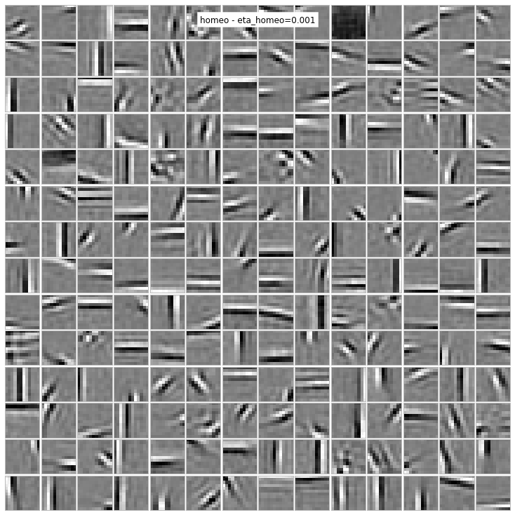

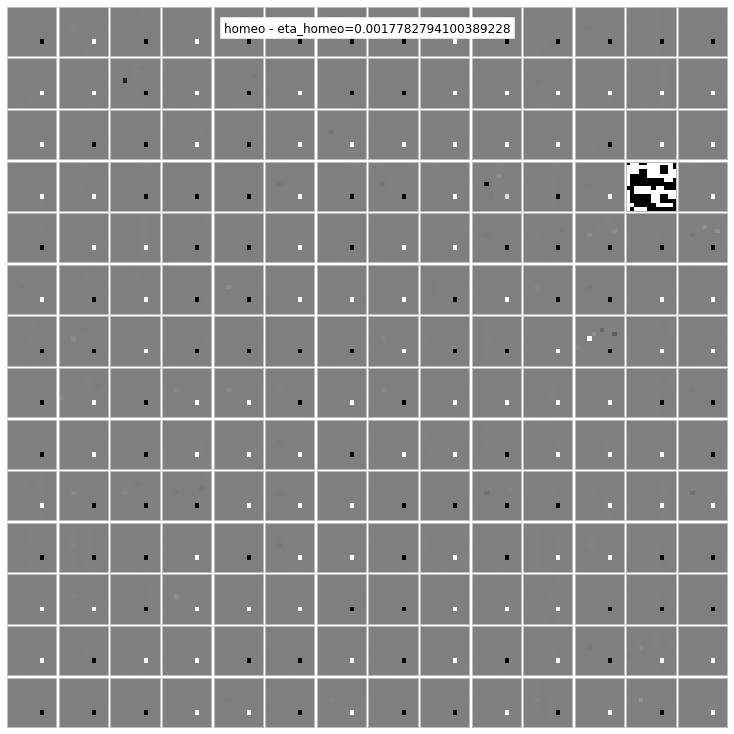

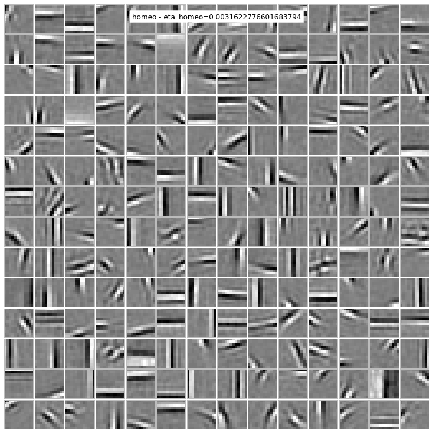

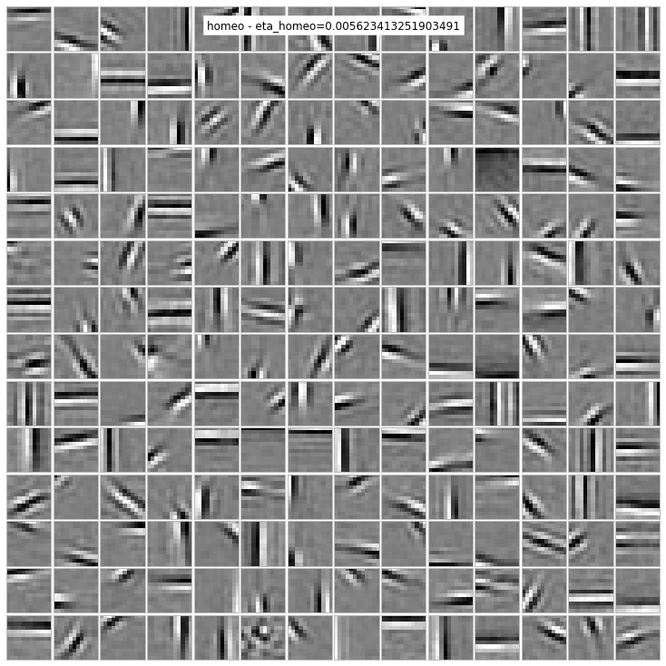

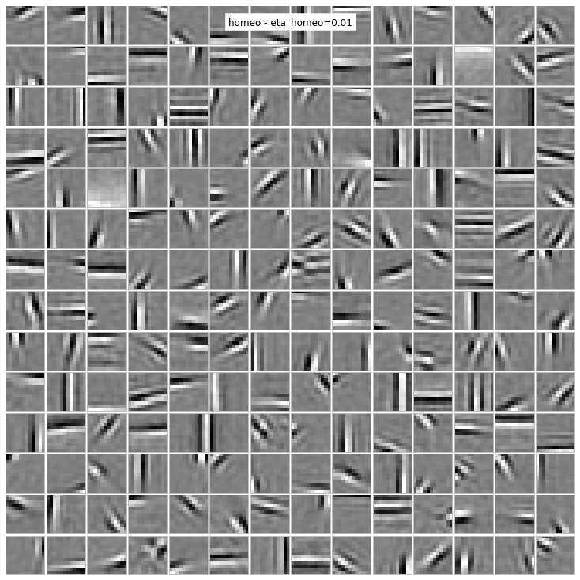

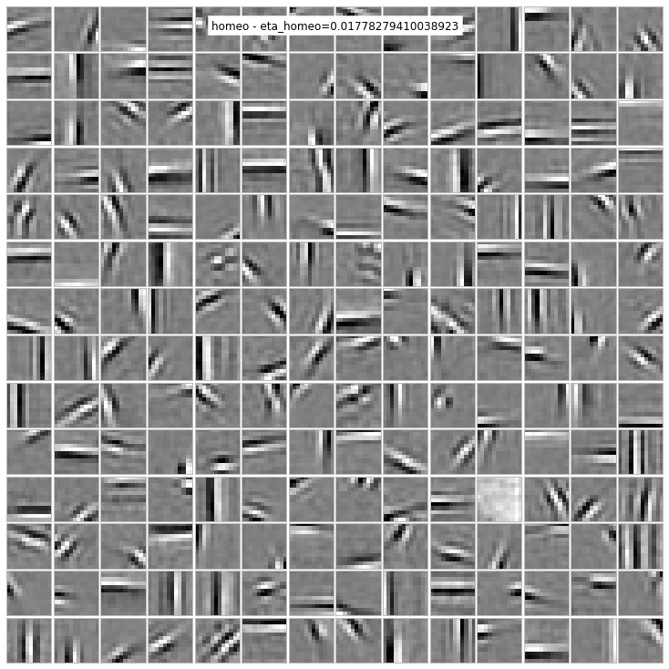

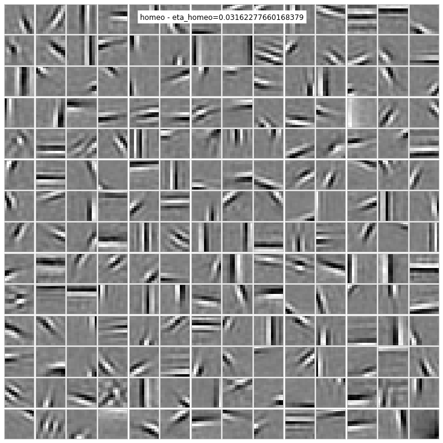

```python
for eta_homeo in np.logspace(-3., -1.5, N_scan, base=10):
    shl = SHL(DEBUG_DOWNSCALE=DEBUG_DOWNSCALE,
              learning_algorithm='omp', database=database,
              transform_n_nonzero_coefs=10, eta_homeo=eta_homeo, verbose=verbose)
    dico = shl.learn_dico()
    _ = shl.show_dico(dico, title='homeo - eta_homeo={}'.format(eta_homeo))
```

### 3. with different smoothing parameters for the homestatic gain

```
0.00316227766017
0.00749894209332
0.0177827941004
0.0421696503429
0.1
0.237137370566
0.56234132519
```

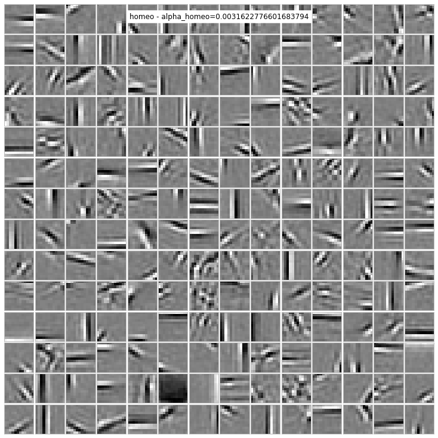

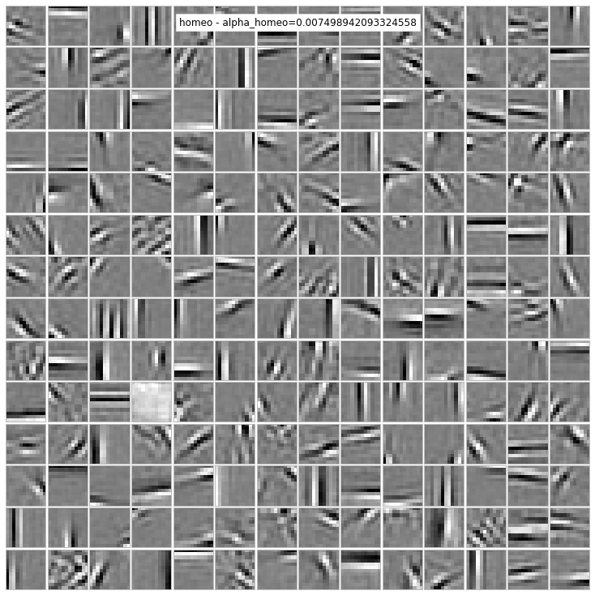

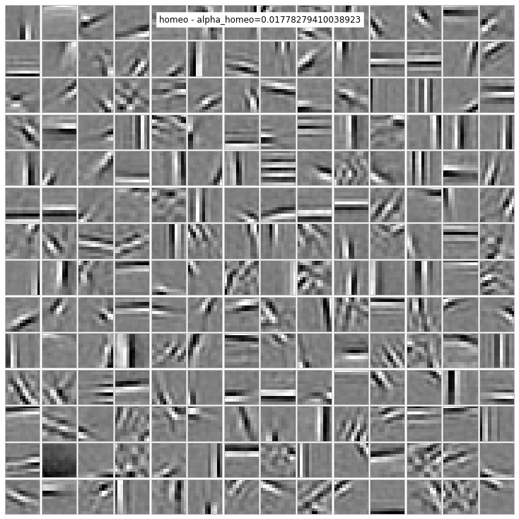

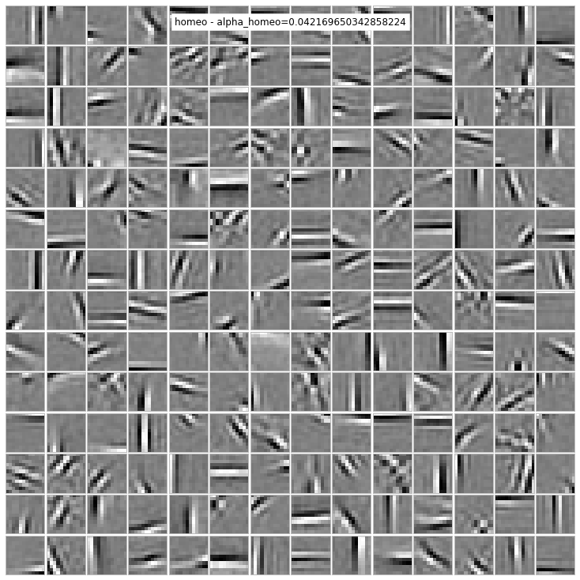

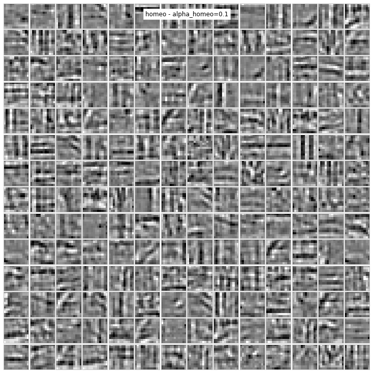

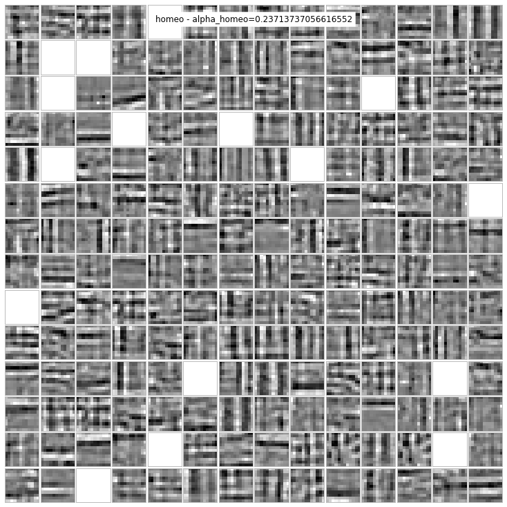

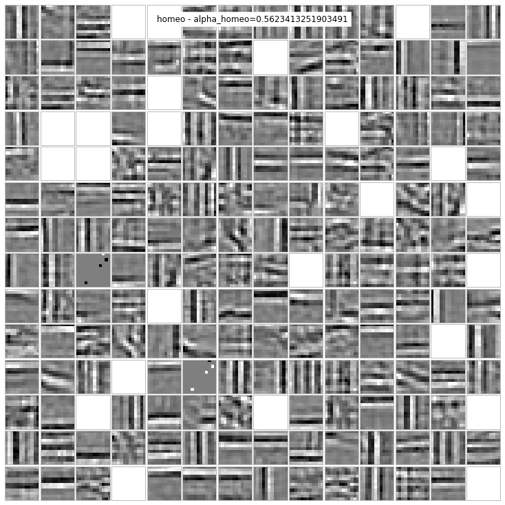

```python
for alpha_homeo in np.logspace(-2.5, -0.25, N_scan, base=10):
    print(alpha_homeo)
    shl = SHL(DEBUG_DOWNSCALE=DEBUG_DOWNSCALE, database=database,
              learning_algorithm='omp', alpha_homeo=alpha_homeo, verbose=verbose)
    dico = shl.learn_dico()
    _ = shl.show_dico(dico, title='homeo - alpha_homeo={}'.format(alpha_homeo))
```